# Homework 4

Ben Chu

May 2, 2018

loading in packages/data and then doing a little cleaning

```r
library(tidyverse)
library(car)
library(psych)
library(forecast)
library(purrr)
library(lmtest)
load("C:/Users/Branly Mclanbry/Downloads/heat.RData")

hw1 <- heat %>%
  janitor::clean_names()%>%
  mutate(date.fac = factor(date))

var <- list(hw1$nviolent,hw1$rape,hw1$rob)
names <- c("crime","rape","robbery")
```

writing a function and then just mapping it across the three variables

```r
dur_pan_box <- function(x,name){
  mod <- lm(x ~ year + temp + age, hw1)

  print(name)
  print(summary(mod))
  dwtest(mod)

  x79 <- acf(residuals(mod), ci = .79, main = paste(name, "(1.25 ACF/SE criteria)"))
  x89 <- acf(residuals(mod), ci = .89, main = paste(name, "(1.60 ACF/SE criteria)"))
  print(x79)
  print(x89)
  test<- lapply(1:6,function(x){
    Box.test(residuals(mod),lag = x, type = "Ljung-Box")
  })

  print(test)
  }
```

# 1a

```r
walk2(var,names,dur_pan_box)
```

```
## [1] "crime"
##
## Call:
## lm(formula = x ~ year + temp + age, data = hw1)
##
## Residuals:
##     Min      1Q  Median      3Q     Max
## -270.43  -68.90   14.47   75.45  220.23
##
## Coefficients:
##              Estimate Std. Error t value Pr(>|t|)
## (Intercept) -2615.767   1650.801  -1.585    0.121
## year           29.231      1.735  16.845   <2e-16 ***
## temp          -12.575     28.674  -0.439    0.663
## age           109.701      7.917  13.856   <2e-16 ***
## ---
## Signif. codes:  0 '***' 0.001 '**' 0.01 '*' 0.05 '.' 0.1 ' ' 1
##
## Residual standard error: 122.4 on 42 degrees of freedom
## Multiple R-squared:  0.9625, Adjusted R-squared:  0.9599
## F-statistic: 359.7 on 3 and 42 DF,  p-value: < 2.2e-16
```

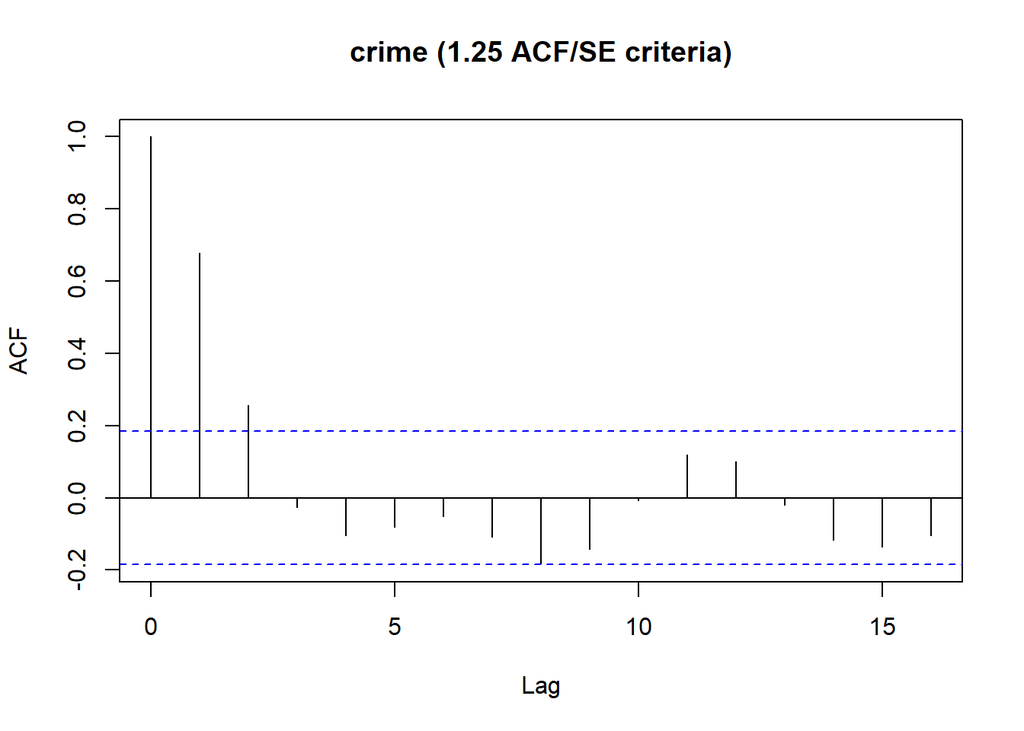

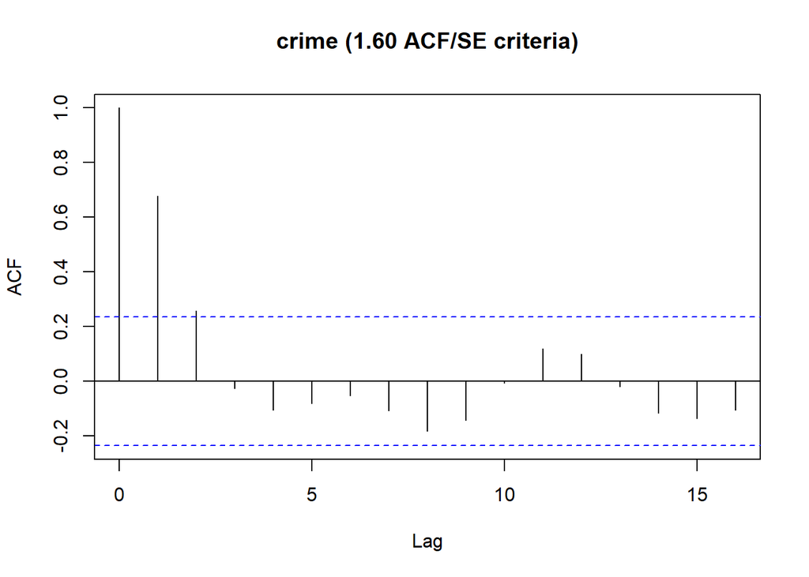

```
##
## Autocorrelations of series 'residuals(mod)', by lag
##
##      0      1      2      3      4      5      6      7      8      9
##  1.000  0.678  0.257 -0.027 -0.105 -0.081 -0.053 -0.108 -0.183 -0.143
##     10     11     12     13     14     15     16
## -0.007  0.119  0.099 -0.019 -0.116 -0.135 -0.105
##
## Autocorrelations of series 'residuals(mod)', by lag
##
##      0      1      2      3      4      5      6      7      8      9
##  1.000  0.678  0.257 -0.027 -0.105 -0.081 -0.053 -0.108 -0.183 -0.143
##     10     11     12     13     14     15     16
## -0.007  0.119  0.099 -0.019 -0.116 -0.135 -0.105
## [[1]]
##
##  Box-Ljung test
##
## data:  residuals(mod)
## X-squared = 22.575, df = 1, p-value = 2.021e-06
##
##
## [[2]]
##
##  Box-Ljung test
##
## data:  residuals(mod)
## X-squared = 25.892, df = 2, p-value = 2.386e-06
##
##
## [[3]]
##
##  Box-Ljung test
##
## data:  residuals(mod)
## X-squared = 25.929, df = 3, p-value = 9.87e-06
##
##
## [[4]]
##
```

[output cut: 28 more lines]

```
##     Min      1Q  Median      3Q     Max
## -3.9092 -2.4625 -0.4771  1.7185  6.4265
##
## Coefficients:
##               Estimate Std. Error t value Pr(>|t|)
## (Intercept) -208.68254   39.89504  -5.231 5.02e-06 ***
## year           0.73464    0.04194  17.518  < 2e-16 ***
## temp           2.73791    0.69296   3.951 0.000292 ***
## age            0.90992    0.19133   4.756 2.34e-05 ***
## ---
## Signif. codes:  0 '***' 0.001 '**' 0.01 '*' 0.05 '.' 0.1 ' ' 1
##
## Residual standard error: 2.959 on 42 degrees of freedom
## Multiple R-squared:  0.9468, Adjusted R-squared:  0.943
## F-statistic: 249.2 on 3 and 42 DF,  p-value: < 2.2e-16
```

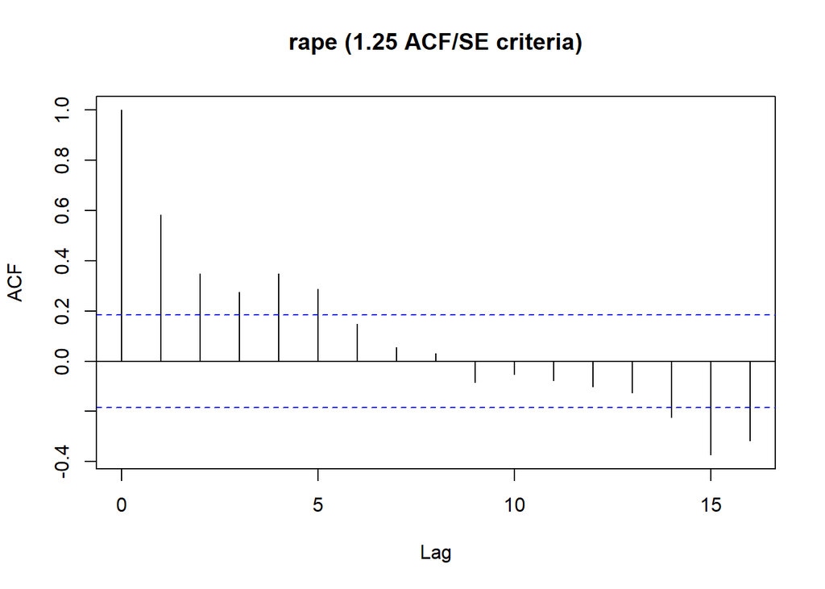

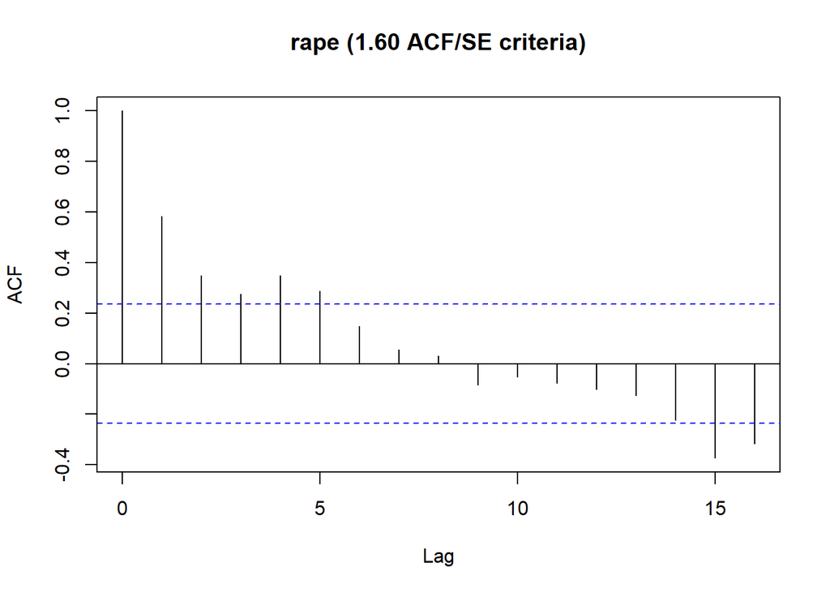

```
##
## Autocorrelations of series 'residuals(mod)', by lag
##
##      0      1      2      3      4      5      6      7      8      9
##  1.000  0.583  0.348  0.274  0.348  0.288  0.147  0.056  0.031 -0.083
##     10     11     12     13     14     15     16
## -0.052 -0.077 -0.102 -0.125 -0.223 -0.373 -0.316
##
## Autocorrelations of series 'residuals(mod)', by lag
##
##      0      1      2      3      4      5      6      7      8      9
##  1.000  0.583  0.348  0.274  0.348  0.288  0.147  0.056  0.031 -0.083
##     10     11     12     13     14     15     16
## -0.052 -0.077 -0.102 -0.125 -0.223 -0.373 -0.316
## [[1]]
##
##  Box-Ljung test
##
## data:  residuals(mod)
## X-squared = 16.666, df = 1, p-value = 4.458e-05
##
##
## [[2]]
##
##  Box-Ljung test
##
## data:  residuals(mod)
## X-squared = 22.752, df = 2, p-value = 1.147e-05
##
##
## [[3]]
##
##  Box-Ljung test
##
## data:  residuals(mod)
## X-squared = 26.615, df = 3, p-value = 7.089e-06
##
##
## [[4]]
##
```

[output cut: 28 more lines]

```
##     Min      1Q  Median      3Q     Max
## -30.742 -14.025  -0.746  12.239  36.961
##
## Coefficients:
##              Estimate Std. Error t value Pr(>|t|)
## (Intercept) -988.3235   244.8099  -4.037 0.000225 ***
## year           4.8053     0.2573  18.673  < 2e-16 ***
## temp           9.6406     4.2522   2.267 0.028588 *
## age           10.0275     1.1741   8.541 9.98e-11 ***
## ---
## Signif. codes:  0 '***' 0.001 '**' 0.01 '*' 0.05 '.' 0.1 ' ' 1
##
## Residual standard error: 18.16 on 42 degrees of freedom
## Multiple R-squared:  0.9582, Adjusted R-squared:  0.9552
## F-statistic: 320.6 on 3 and 42 DF,  p-value: < 2.2e-16
```

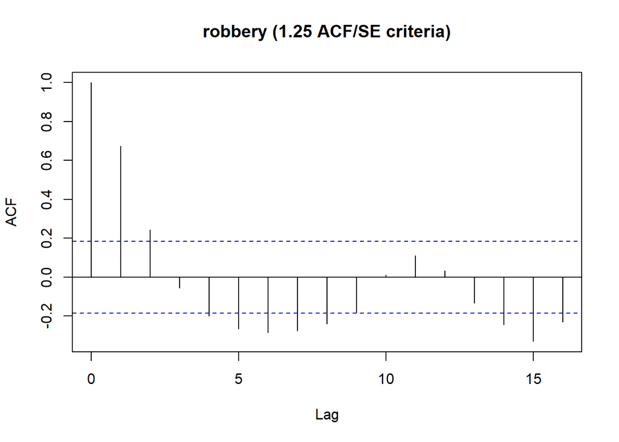

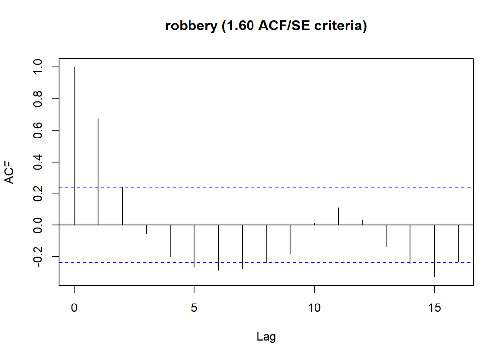

```
##
## Autocorrelations of series 'residuals(mod)', by lag
##
##      0      1      2      3      4      5      6      7      8      9
##  1.000  0.674  0.243 -0.055 -0.200 -0.264 -0.283 -0.273 -0.239 -0.182
##     10     11     12     13     14     15     16
##  0.012  0.111  0.033 -0.132 -0.245 -0.330 -0.231
##
## Autocorrelations of series 'residuals(mod)', by lag
##
##      0      1      2      3      4      5      6      7      8      9
##  1.000  0.674  0.243 -0.055 -0.200 -0.264 -0.283 -0.273 -0.239 -0.182
##     10     11     12     13     14     15     16
##  0.012  0.111  0.033 -0.132 -0.245 -0.330 -0.231
## [[1]]
##
##  Box-Ljung test
##
## data:  residuals(mod)
## X-squared = 22.289, df = 1, p-value = 2.346e-06
##
##
## [[2]]
##
##  Box-Ljung test
##
## data:  residuals(mod)
## X-squared = 25.251, df = 2, p-value = 3.288e-06
##
##
## [[3]]
##
##  Box-Ljung test
##
## data:  residuals(mod)
## X-squared = 25.407, df = 3, p-value = 1.269e-05
##
##
## [[4]]
##
##  Box-Ljung test
##
## data:  residuals(mod)
## X-squared = 27.51, df = 4, p-value = 1.567e-05
##
##
## [[5]]
##
##  Box-Ljung test
##
## data:  residuals(mod)
## X-squared = 31.265, df = 5, p-value = 8.305e-06
##
##
## [[6]]
##
##  Box-Ljung test
##
## data:  residuals(mod)
## X-squared = 35.69, df = 6, p-value = 3.167e-06
```

Writing an ARIMA function

```r
pred <- select(hw1,temp,age,year)
arimar <- function(x){
  for(i in 1:3){
  armod <- Arima(hw1[x], xreg = pred, order = c(i,0,0))

  acf(residuals(armod), ci = .79, main = paste(x, "(1.25 ACF/SE criteria)"))
  acf(residuals(armod), ci = .89, main = paste(x, "(1.60 ACF/SE criteria)"))

  sapply(1:6, function(x){
    print(Box.test(residuals(armod),lag = x, type = "Ljung-Box"))
  })
  print("t values")
  print(as.list((armod$coef)/sqrt(diag(armod$var.coef))))
  print("p values")
  print(as.list((1-pnorm(abs(armod$coef)/sqrt(diag(armod$var.coef))))*2))
  print(armod)
  }
}
```

# 1b,

It looks like 2 autocorrelative terms were used for robbery and property crimer, while 1 autocorrelative term was used for rape.

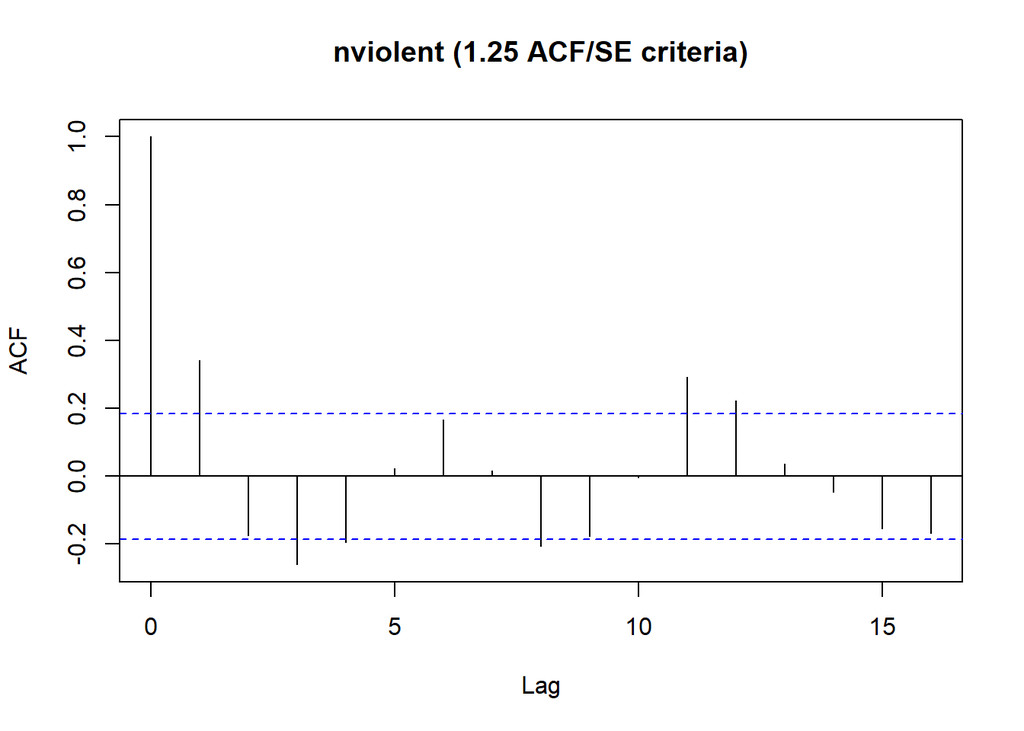

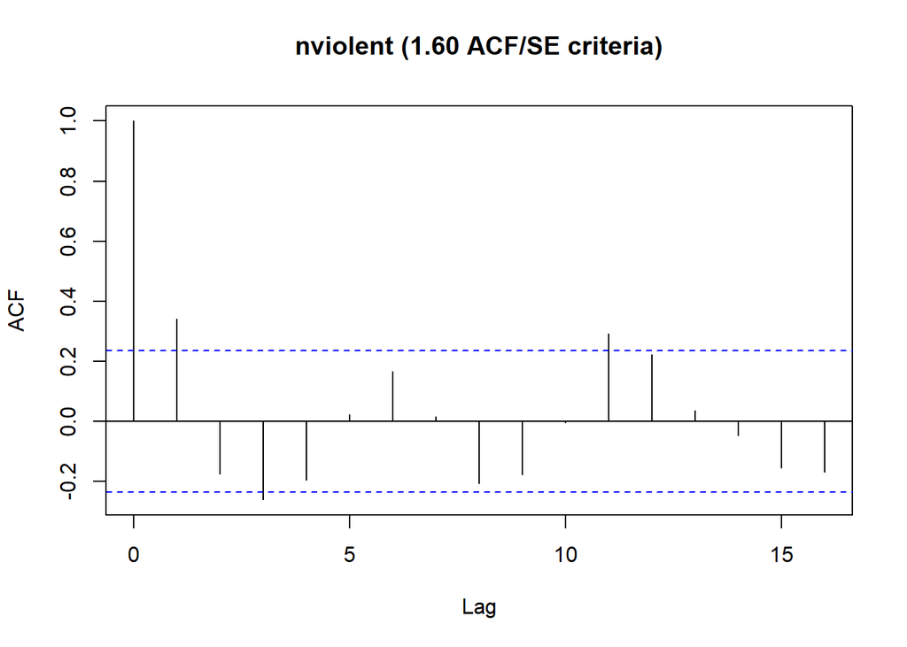

```
##
##  Box-Ljung test
##
## data:  residuals(armod)
## X-squared = 5.7457, df = 1, p-value = 0.01653
##
##
##  Box-Ljung test
##
## data:  residuals(armod)
## X-squared = 7.2621, df = 2, p-value = 0.02649
##
##
##  Box-Ljung test
##
## data:  residuals(armod)
## X-squared = 10.739, df = 3, p-value = 0.01322
##
##
##  Box-Ljung test
##
## data:  residuals(armod)
## X-squared = 12.75, df = 4, p-value = 0.01256
##
##
##  Box-Ljung test
##
## data:  residuals(armod)
## X-squared = 12.779, df = 5, p-value = 0.02554
##
##
##  Box-Ljung test
##
## data:  residuals(armod)
## X-squared = 14.311, df = 6, p-value = 0.02635
##
## [1] "t values"
## $ar1
## [1] 7.171522
##
```

[output cut: 23 more lines]

```
## [1] 6.001276e-05
##
## $year
## [1] 4.640732e-14
##
## Series: hw1[x]
## Regression with ARIMA(1,0,0) errors
##
## Coefficients:
##          ar1  intercept     temp      age     year
##       0.8371  -3378.521   6.0592  92.0464  29.9810
## s.e.  0.1167   1043.024  16.9295  22.9384   3.9753
##
## sigma^2 estimated as 6649:  log likelihood=-265.68
## AIC=543.36   AICc=545.51   BIC=554.33
```

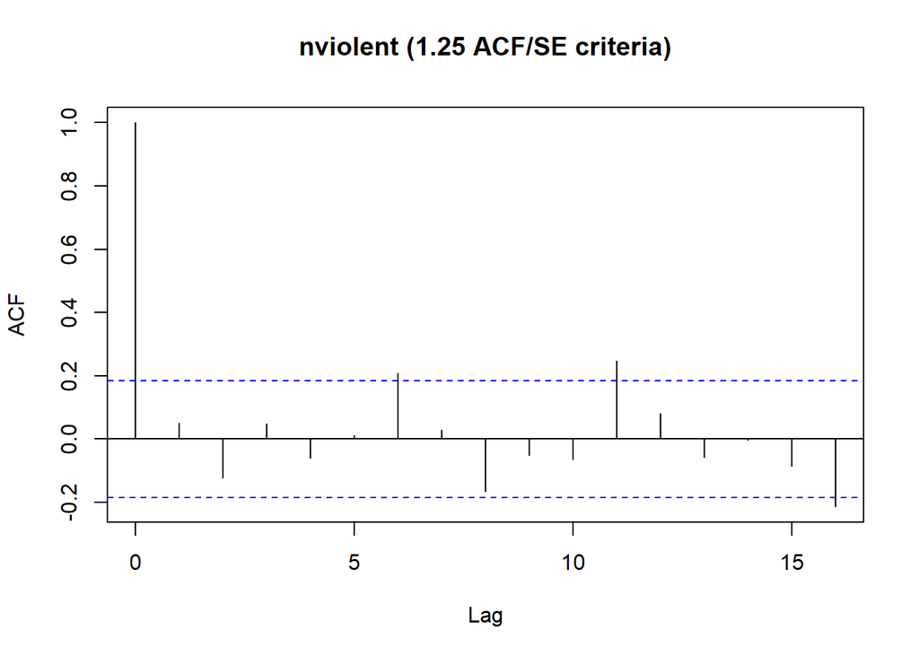

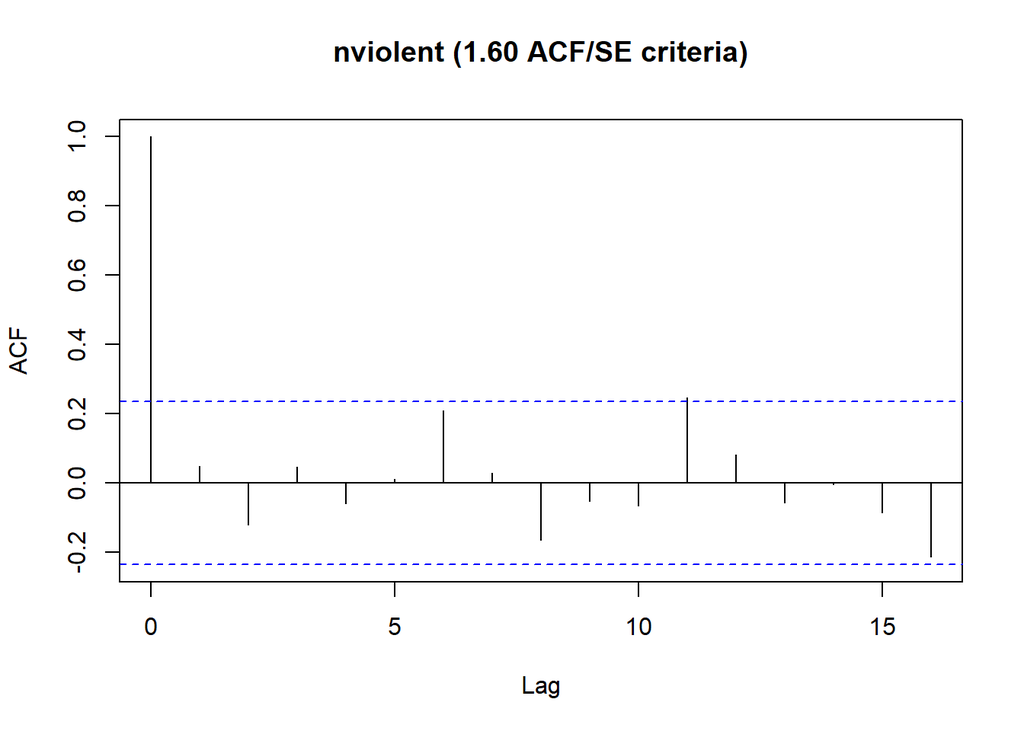

```
##
##  Box-Ljung test
##
## data:  residuals(armod)
## X-squared = 0.11993, df = 1, p-value = 0.7291
##
##
##  Box-Ljung test
##
## data:  residuals(armod)
## X-squared = 0.86502, df = 2, p-value = 0.6489
##
##
##  Box-Ljung test
##
## data:  residuals(armod)
## X-squared = 0.97954, df = 3, p-value = 0.8062
##
##
##  Box-Ljung test
##
## data:  residuals(armod)
## X-squared = 1.1671, df = 4, p-value = 0.8835
##
##
##  Box-Ljung test
##
## data:  residuals(armod)
## X-squared = 1.1744, df = 5, p-value = 0.9473
##
##
##  Box-Ljung test
##
## data:  residuals(armod)
## X-squared = 3.5797, df = 6, p-value = 0.7333
##
## [1] "t values"
## $ar1
## [1] 8.434694
##
```

[output cut: 29 more lines]

```
## [1] 6.71907e-13
##
## $year
## [1] 0
##
## Series: hw1[x]
## Regression with ARIMA(2,0,0) errors
##
## Coefficients:
##          ar1      ar2   intercept     temp       age     year
##       1.1763  -0.5086  -3044.6082  -2.3656  101.0238  29.6711
## s.e.  0.1395   0.1366    747.2463  12.6226   14.0603   2.5213
##
## sigma^2 estimated as 5263:  log likelihood=-259.9
## AIC=533.79   AICc=536.74   BIC=546.59
```

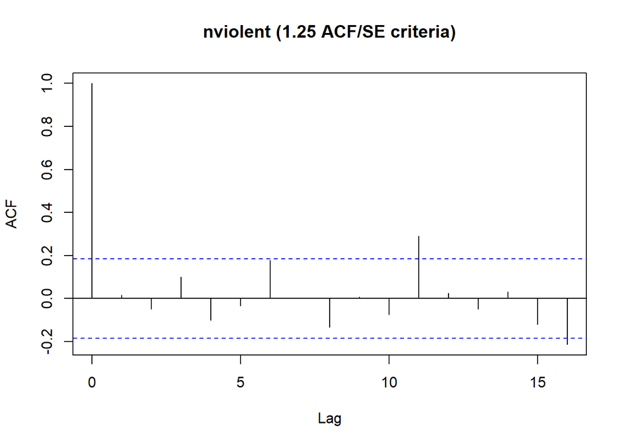

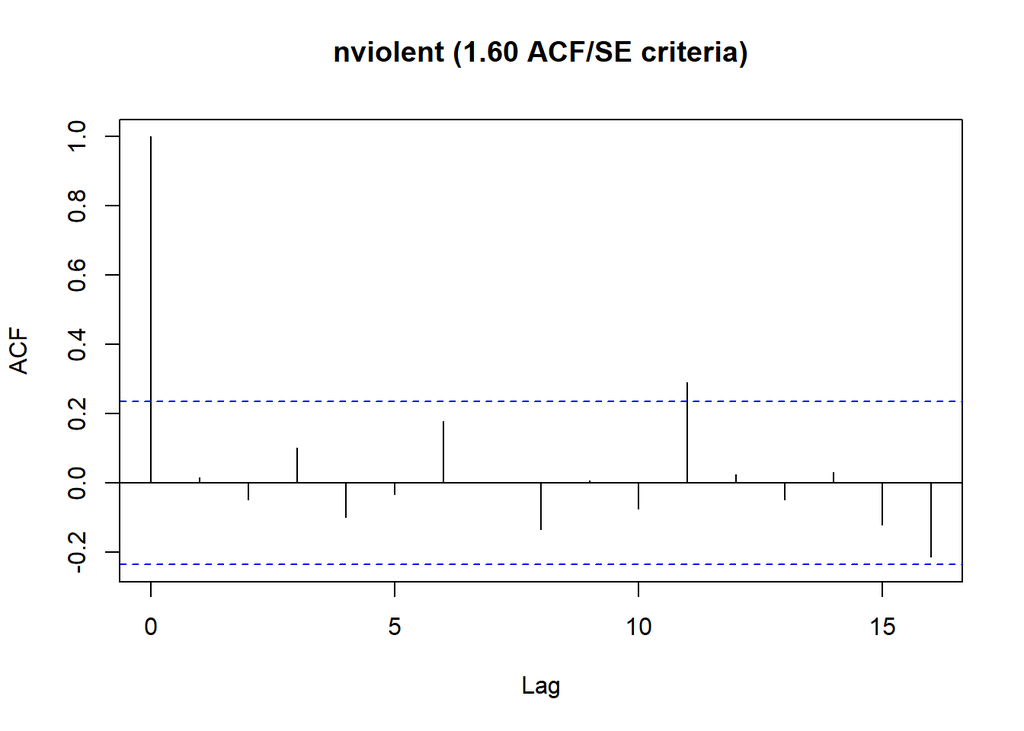

```
##
##  Box-Ljung test
##
## data:  residuals(armod)
## X-squared = 0.012435, df = 1, p-value = 0.9112
##
##
##  Box-Ljung test
##
## data:  residuals(armod)
## X-squared = 0.134, df = 2, p-value = 0.9352
##
##
##  Box-Ljung test
##
## data:  residuals(armod)
## X-squared = 0.65119, df = 3, p-value = 0.8846
##
##
##  Box-Ljung test
##
## data:  residuals(armod)
## X-squared = 1.1738, df = 4, p-value = 0.8824
##
##
##  Box-Ljung test
##
## data:  residuals(armod)
## X-squared = 1.2334, df = 5, p-value = 0.9416
##
##
##  Box-Ljung test
##
## data:  residuals(armod)
## X-squared = 2.9688, df = 6, p-value = 0.8128
##
## [1] "t values"
## $ar1
## [1] 7.600998
##
```

[output cut: 35 more lines]

```
## [1] 0.04097473
##
## $year
## [1] 5.413252e-08
##
## Series: hw1[x]
## Regression with ARIMA(3,0,0) errors
##
## Coefficients:
##          ar1      ar2    ar3   intercept     temp      age     year
##       1.4792  -0.8890  0.321  -2480.8220   1.1904  62.7580  30.5219
## s.e.  0.1946   0.2512  0.149    963.6393  10.0259  30.7068   5.6136
##
## sigma^2 estimated as 5007:  log likelihood=-258.69
## AIC=533.37   AICc=537.27   BIC=548
```

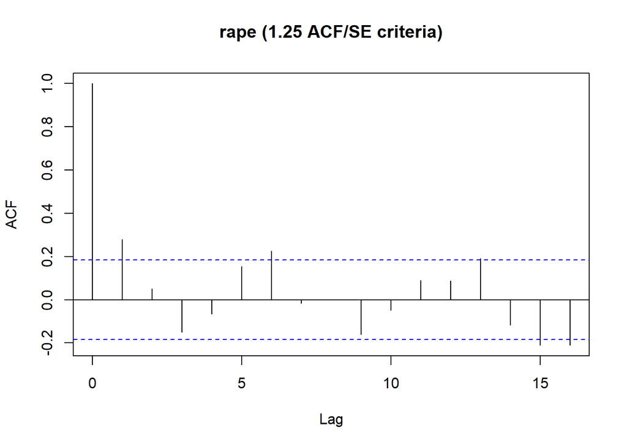

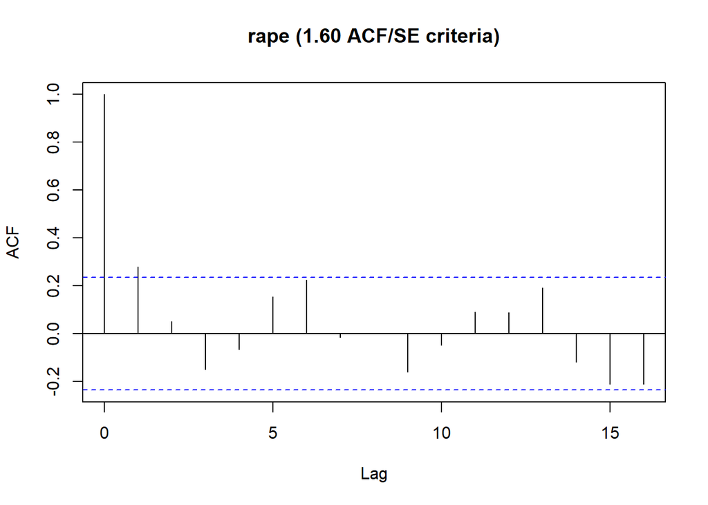

```
##
##  Box-Ljung test
##
## data:  residuals(armod)
## X-squared = 3.8039, df = 1, p-value = 0.05113
##
##
##  Box-Ljung test
##
## data:  residuals(armod)
## X-squared = 3.9338, df = 2, p-value = 0.1399
##
##
##  Box-Ljung test
##
## data:  residuals(armod)
## X-squared = 5.0864, df = 3, p-value = 0.1656
##
##
##  Box-Ljung test
##
## data:  residuals(armod)
## X-squared = 5.3079, df = 4, p-value = 0.2571
##
##
##  Box-Ljung test
##
## data:  residuals(armod)
## X-squared = 6.5857, df = 5, p-value = 0.2533
##
##
##  Box-Ljung test
##
## data:  residuals(armod)
## X-squared = 9.3773, df = 6, p-value = 0.1534
##
## [1] "t values"
## $ar1
## [1] 16.35108
##
```

[output cut: 23 more lines]

```
## [1] 0.1584199
##
## $year
## [1] 1.790137e-08
##
## Series: hw1[x]
## Regression with ARIMA(1,0,0) errors
##
## Coefficients:
##          ar1  intercept    temp     age    year
##       0.9178   -51.2869  0.2430  0.5631  0.6645
## s.e.  0.0561    20.7611  0.2991  0.3993  0.1180
##
## sigma^2 estimated as 2.252:  log likelihood=-82.22
## AIC=176.43   AICc=178.59   BIC=187.41
```

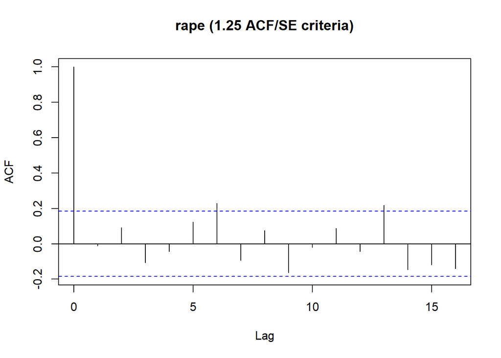

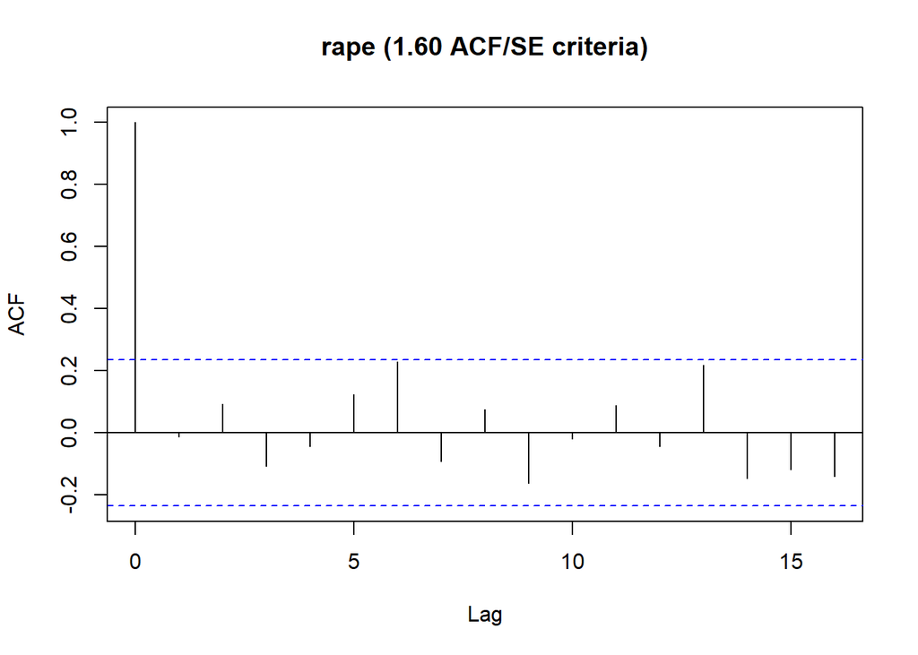

```
##
##  Box-Ljung test
##
## data:  residuals(armod)
## X-squared = 0.0075147, df = 1, p-value = 0.9309
##
##
##  Box-Ljung test
##
## data:  residuals(armod)
## X-squared = 0.43729, df = 2, p-value = 0.8036
##
##
##  Box-Ljung test
##
## data:  residuals(armod)
## X-squared = 1.0294, df = 3, p-value = 0.7941
##
##
##  Box-Ljung test
##
## data:  residuals(armod)
## X-squared = 1.1272, df = 4, p-value = 0.8899
##
##
##  Box-Ljung test
##
## data:  residuals(armod)
## X-squared = 1.9591, df = 5, p-value = 0.8548
##
##
##  Box-Ljung test
##
## data:  residuals(armod)
## X-squared = 4.8657, df = 6, p-value = 0.5611
##
## [1] "t values"
## $ar1
## [1] 7.704022
##
```

[output cut: 29 more lines]

```
## [1] 0.588576
##
## $year
## [1] 8.851309e-08
##
## Series: hw1[x]
## Regression with ARIMA(2,0,0) errors
##
## Coefficients:
##          ar1      ar2  intercept    temp     age    year
##       1.2548  -0.3486   -43.1601  0.1686  0.2817  0.6968
## s.e.  0.1629   0.1535    20.2004  0.2437  0.5209  0.1303
##
## sigma^2 estimated as 2.055:  log likelihood=-79.75
## AIC=173.51   AICc=176.46   BIC=186.31
```

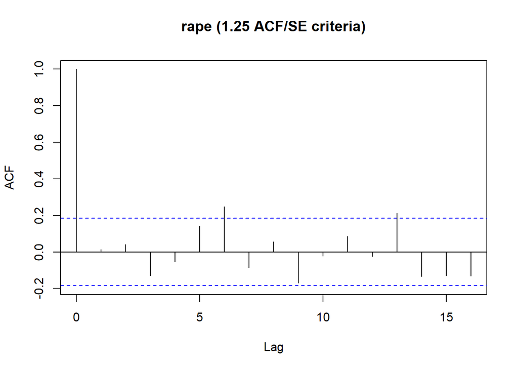

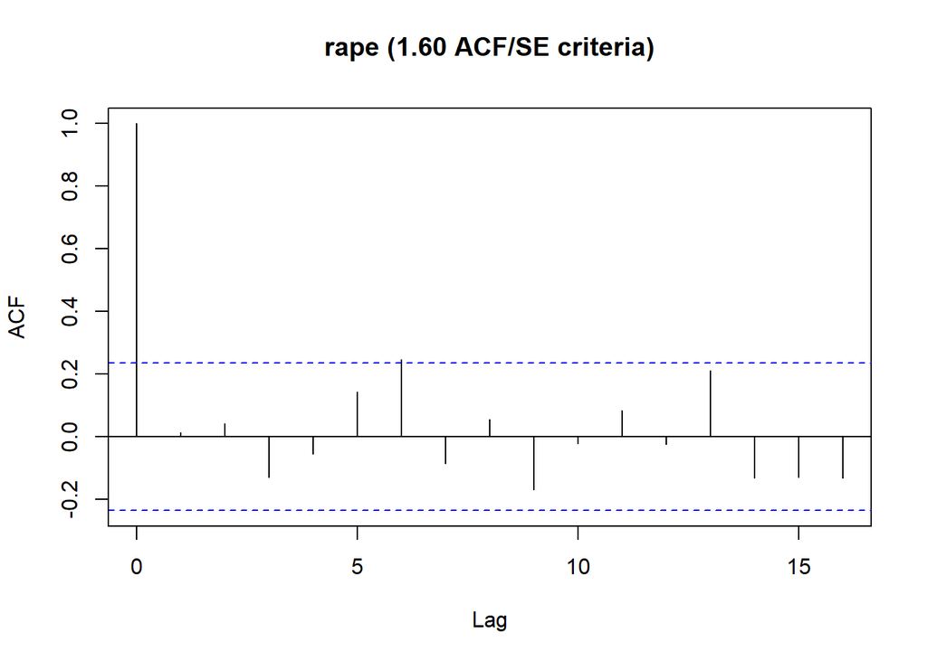

```
##
##  Box-Ljung test
##
## data:  residuals(armod)
## X-squared = 0.0099142, df = 1, p-value = 0.9207
##
##
##  Box-Ljung test
##
## data:  residuals(armod)
## X-squared = 0.099213, df = 2, p-value = 0.9516
##
##
##  Box-Ljung test
##
## data:  residuals(armod)
## X-squared = 0.95973, df = 3, p-value = 0.811
##
##
##  Box-Ljung test
##
## data:  residuals(armod)
## X-squared = 1.1129, df = 4, p-value = 0.8922
##
##
##  Box-Ljung test
##
## data:  residuals(armod)
## X-squared = 2.2169, df = 5, p-value = 0.8184
##
##
##  Box-Ljung test
##
## data:  residuals(armod)
## X-squared = 5.5929, df = 6, p-value = 0.4703
##
## [1] "t values"
## $ar1
## [1] 7.560722
##
```

[output cut: 35 more lines]

```
## [1] 0.7931582
##
## $year
## [1] 3.816111e-07
##
## Series: hw1[x]
## Regression with ARIMA(3,0,0) errors
##
## Coefficients:
##          ar1      ar2      ar3  intercept    temp     age    year
##       1.2487  -0.2670  -0.0759   -42.0824  0.1894  0.1693  0.7000
## s.e.  0.1652   0.2422   0.1757    21.0882  0.2513  0.6458  0.1378
##
## sigma^2 estimated as 2.093:  log likelihood=-79.66
## AIC=175.32   AICc=179.21   BIC=189.95
```

[6 more figures not shown]

```
##
##  Box-Ljung test
##
## data:  residuals(armod)
## X-squared = 0.089926, df = 1, p-value = 0.7643
##
##
##  Box-Ljung test
##
## data:  residuals(armod)
## X-squared = 0.4504, df = 2, p-value = 0.7984
##
##
##  Box-Ljung test
##
## data:  residuals(armod)
## X-squared = 0.60769, df = 3, p-value = 0.8947
##
##
##  Box-Ljung test
##
## data:  residuals(armod)
## X-squared = 1.3913, df = 4, p-value = 0.8457
##
##
##  Box-Ljung test
##
## data:  residuals(armod)
## X-squared = 1.698, df = 5, p-value = 0.8892
##
##
##  Box-Ljung test
##
## data:  residuals(armod)
## X-squared = 1.9844, df = 6, p-value = 0.9211
##
## [1] "t values"
## $ar1
## [1] 8.789139
##
```

[output cut: 35 more lines]

```
## [1] 1.097142e-09
##
## $year
## [1] 0
##
## Series: hw1[x]
## Regression with ARIMA(3,0,0) errors
##
## Coefficients:
##          ar1      ar2     ar3  intercept    temp     age    year
##       1.3055  -0.7523  0.0989  -493.8748  1.0749  9.6350  4.9142
## s.e.  0.1485   0.2186  0.1501    94.0614  1.5464  1.5809  0.3256
##
## sigma^2 estimated as 98.35:  log likelihood=-167.97
## AIC=351.93   AICc=355.82   BIC=366.56
```

```r
map(c("nviolent","rape","rob"),arimar)
```

# 1c

Anderson and his colleagues utilized Box-Ljung/chi-square tests for autocorrelations/fit. It looks like they used six lags for residuals.

# 1d

A model predicting violence from temperature, year, and age indicated issues with autocorrelation. Two autoregressive terms were used in the Arima Model.Year (*b* = 29.67, *p* < .001) and age (*b* = 101.02, *p* < .001) were significant while temperature (*b* = -2.36, *p* = .85) were not

A model predicting rape from temperature, year, and age indicated issues with autocorrelation. One autoregressive terms were used in the Arima Model.Year (*b* = 0.66, *p* < .001) was significant but age (*b* = 0.56, *p* = .16) and temperature (*b* = 0.24, *p* = .41) were not

A model predicting Robbery from temperature, year, and age indicated issues with autocorrelation. Two autoregressive terms were used in the Arima Model.Year (*b* = 4.90, *p* < .001) and age (*b* = 9.76, *p* < .001) but temperature (*b* = 1.18, *p* = .46) were not.

ACF and Pankrantz criteria were used, but ultimately ignored. I just looked at the Box-Ljung until it hit over .05 for the lags and called it good. This led me to the ARIMA models andI found which autoregressive terms that were the *best*. Year seems to be significant for all models but age fluctuates and temperature is not significant at all.

# 2a

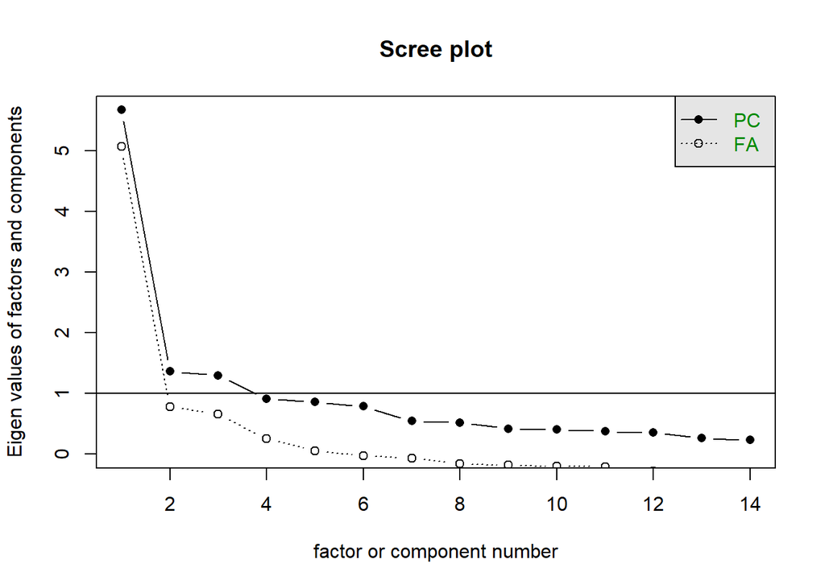

```r
load("C:/Users/Branly Mclanbry/Downloads/schumm.RData")
scree(schumm)
```

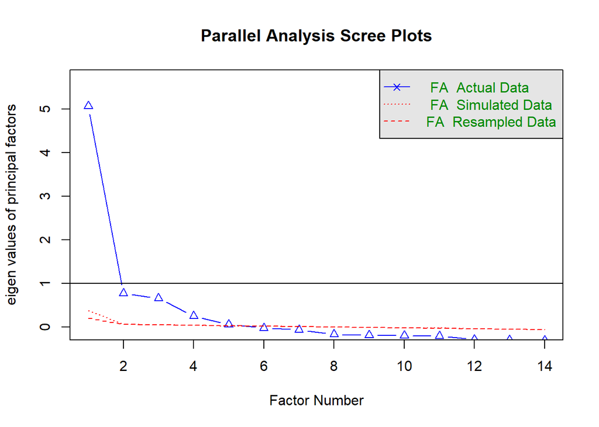

```
## Parallel analysis suggests that the number of factors =  5  and the number of components =  NA
```

```r
fa.parallel(schumm, fa = "fa")
```

```r
vss(schumm, rotate = "varimax", fm = "fa")
```

[output not shown]

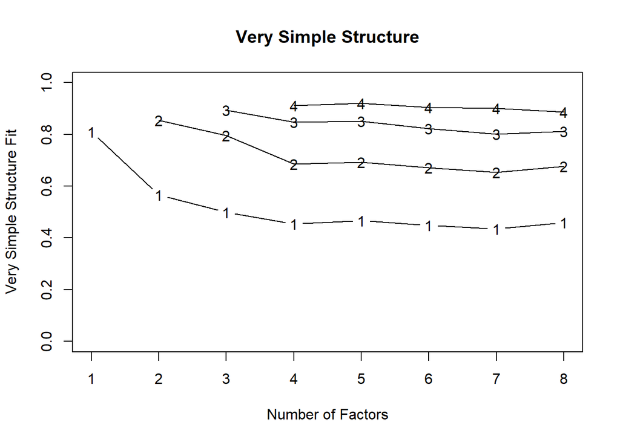

```
##
## Very Simple Structure
## Call: vss(x = schumm, rotate = "varimax", fm = "fa")
## VSS complexity 1 achieves a maximimum of 0.81  with  1  factors
## VSS complexity 2 achieves a maximimum of 0.85  with  2  factors
##
## The Velicer MAP achieves a minimum of 0.03  with  3  factors
## BIC achieves a minimum of  -77.08  with  7  factors
## Sample Size adjusted BIC achieves a minimum of  -32.59  with  7  factors
##
## Statistics by number of factors
##   vss1 vss2   map dof chisq    prob sqresid  fit RMSEA      BIC SABIC
## 1 0.81 0.00 0.034  77 13010 0.0e+00     7.4 0.81 0.152 12325.29 12570
## 2 0.57 0.85 0.033  64  7445 0.0e+00     5.7 0.85 0.126  6875.82  7079
## 3 0.50 0.80 0.031  52  2469 0.0e+00     4.2 0.89 0.080  2006.32  2172
## 4 0.45 0.69 0.036  41   563 5.3e-93     3.5 0.91 0.042   198.64   329
## 5 0.47 0.69 0.053  31   276 4.2e-41     2.7 0.93 0.033     0.19    99
## 6 0.45 0.67 0.075  22   152 2.0e-21     2.7 0.93 0.028   -43.67    26
## 7 0.43 0.65 0.095  14    47 1.6e-05     2.4 0.94 0.018   -77.08   -33
## 8 0.46 0.68 0.132   7    22 2.9e-03     2.2 0.95 0.017   -40.59   -18
##   complex  eChisq   SRMR  eCRMS  eBIC
## 1     1.0 11062.7 0.0912 0.0991 10378
## 2     1.4  5956.0 0.0669 0.0798  5387
## 3     1.6  1580.7 0.0345 0.0456  1118
## 4     1.8   328.9 0.0157 0.0234   -36
## 5     1.7   140.2 0.0103 0.0176  -136
## 6     1.8    50.4 0.0062 0.0125  -145
## 7     1.9    13.1 0.0031 0.0080  -111
## 8     1.9     6.8 0.0023 0.0081   -56
```

```r
yy<-fa(schumm, nfactors = 4, rotate = "varimax", fm = "pa")
fa.sort(yy)
```

```
## Factor Analysis using method =  pa
## Call: fa(r = schumm, nfactors = 4, rotate = "varimax", fm = "pa")
## Standardized loadings (pattern matrix) based upon correlation matrix
##        PA1  PA2  PA3  PA4   h2   u2 com
## q5a2  0.86 0.20 0.18 0.15 0.83 0.17 1.3
## q5a1  0.73 0.23 0.22 0.17 0.66 0.34 1.5
## q5a3  0.70 0.17 0.20 0.15 0.58 0.42 1.4
## q5a23 0.20 0.82 0.14 0.18 0.77 0.23 1.3
## q5a21 0.23 0.75 0.17 0.22 0.69 0.31 1.5
## q5a22 0.22 0.67 0.16 0.31 0.61 0.39 1.8
## q5a18 0.15 0.11 0.80 0.15 0.69 0.31 1.2
## q5a6  0.25 0.15 0.59 0.15 0.46 0.54 1.6
## q5a17 0.34 0.18 0.46 0.34 0.48 0.52 3.2
## q5a24 0.07 0.07 0.35 0.16 0.15 0.85 1.6
## q5a12 0.21 0.15 0.21 0.17 0.14 0.86 3.7
## q5a16 0.19 0.27 0.23 0.72 0.68 0.32 1.7
## q5a14 0.19 0.32 0.16 0.56 0.48 0.52 2.1
## q5a15 0.12 0.14 0.31 0.55 0.43 0.57 1.8
##
##                        PA1  PA2  PA3  PA4
## SS loadings           2.23 2.10 1.74 1.60
## Proportion Var        0.16 0.15 0.12 0.11
## Cumulative Var        0.16 0.31 0.43 0.55
## Proportion Explained  0.29 0.27 0.23 0.21
## Cumulative Proportion 0.29 0.57 0.79 1.00
##
## Mean item complexity =  1.8
## Test of the hypothesis that 4 factors are sufficient.
##
## The degrees of freedom for the null model are  91  and the objective function was  6.04 with Chi Square of  44076.49
## The degrees of freedom for the model are 41  and the objective function was  0.08
##
## The root mean square of the residuals (RMSR) is  0.02
## The df corrected root mean square of the residuals is  0.02
##
## The harmonic number of observations is  7308 with the empirical chi square  328.96  with prob <  1.3e-46
## The total number of observations was  7308  with Likelihood Chi Square =  563.63  with prob <  4.8e-93
##
## Tucker Lewis Index of factoring reliability =  0.974
## RMSEA index =  0.042  and the 90 % confidence intervals are  0.039 0.045
## BIC =  198.86
## Fit based upon off diagonal values = 1
## Measures of factor score adequacy
##                                                    PA1  PA2  PA3  PA4
## Correlation of (regression) scores with factors   0.92 0.90 0.85 0.81
## Multiple R square of scores with factors          0.84 0.80 0.71 0.66
## Minimum correlation of possible factor scores     0.68 0.61 0.43 0.32
```

```r
fa.sort(yy$loadings)
```

```
##
## Loadings:
##       PA1   PA2   PA3   PA4
## q5a2  0.860 0.200 0.181 0.148
## q5a1  0.727 0.234 0.220 0.171
## q5a3  0.701 0.172 0.197 0.152
## q5a23 0.195 0.824 0.143 0.177
## q5a21 0.227 0.750 0.174 0.216
## q5a22 0.220 0.667 0.162 0.306
## q5a18 0.149 0.114 0.797 0.150
## q5a6  0.249 0.148 0.594 0.150
## q5a17 0.343 0.183 0.457 0.343
## q5a24             0.346 0.156
## q5a12 0.209 0.154 0.215 0.174
## q5a16 0.187 0.266 0.235 0.720
## q5a14 0.187 0.318 0.165 0.559
## q5a15 0.120 0.142 0.310 0.550
##
##                  PA1   PA2   PA3   PA4
## SS loadings    2.232 2.100 1.738 1.597
## Proportion Var 0.159 0.150 0.124 0.114
## Cumulative Var 0.159 0.309 0.434 0.548
```

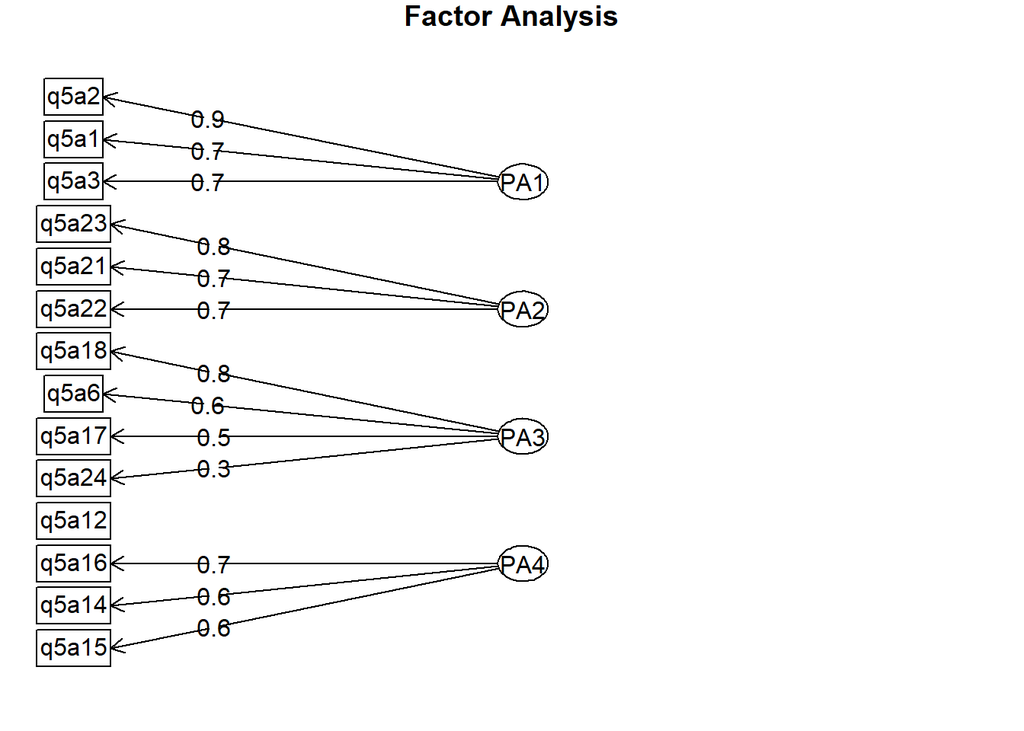

```r
fa.diagram(yy)
```

#2b  
I suppose the editors could have added communalities, total percentage explained and individual contributions, uniqueness, correlations of regressions, multiple R squared, minimum correlations, mean item complexity. I might have added a diagram to explain the factor loadings so it’s easy to read, kinda like the graph I have provided.

# 2c

Frankly, four factors seems to work well. running it with five factors does not increase the amount explained that much (4%).

```r
yyz<-fa(schumm, nfactors = 5, rotate = "varimax", fm = "pa")
```

```
## maximum iteration exceeded
```

```r
fa.sort(yyz)
```

```
## Factor Analysis using method =  pa
## Call: fa(r = schumm, nfactors = 5, rotate = "varimax", fm = "pa")
## Standardized loadings (pattern matrix) based upon correlation matrix
##        PA1  PA2  PA3  PA4  PA5   h2   u2 com
## q5a2  0.86 0.21 0.17 0.15 0.07 0.84 0.16 1.3
## q5a1  0.71 0.23 0.19 0.16 0.24 0.67 0.33 1.8
## q5a3  0.70 0.18 0.19 0.16 0.05 0.59 0.41 1.4
## q5a23 0.19 0.82 0.13 0.18 0.08 0.77 0.23 1.3
## q5a21 0.22 0.75 0.16 0.22 0.08 0.69 0.31 1.5
## q5a22 0.21 0.67 0.15 0.30 0.12 0.61 0.39 1.8
## q5a18 0.15 0.12 0.83 0.16 0.03 0.75 0.25 1.2
## q5a6  0.25 0.15 0.56 0.16 0.13 0.44 0.56 1.8
## q5a17 0.34 0.19 0.44 0.35 0.09 0.48 0.52 3.4
## q5a24 0.06 0.07 0.33 0.15 0.14 0.16 0.84 2.0
## q5a16 0.18 0.27 0.21 0.72 0.09 0.68 0.32 1.6
## q5a15 0.12 0.14 0.29 0.56 0.07 0.43 0.57 1.8
## q5a14 0.18 0.32 0.15 0.55 0.12 0.47 0.53 2.1
## q5a12 0.15 0.12 0.17 0.13 0.60 0.44 0.56 1.5
##
##                        PA1  PA2  PA3  PA4  PA5
## SS loadings           2.17 2.10 1.66 1.60 0.52
## Proportion Var        0.16 0.15 0.12 0.11 0.04
## Cumulative Var        0.16 0.31 0.42 0.54 0.57
## Proportion Explained  0.27 0.26 0.21 0.20 0.06
## Cumulative Proportion 0.27 0.53 0.74 0.94 1.00
##
## Mean item complexity =  1.8
## Test of the hypothesis that 5 factors are sufficient.
##
## The degrees of freedom for the null model are  91  and the objective function was  6.04 with Chi Square of  44076.49
## The degrees of freedom for the model are 31  and the objective function was  0.04
##
## The root mean square of the residuals (RMSR) is  0.01
## The df corrected root mean square of the residuals is  0.02
##
## The harmonic number of observations is  7308 with the empirical chi square  145.56  with prob <  9.2e-17
## The total number of observations was  7308  with Likelihood Chi Square =  284.28  with prob <  1e-42
##
## Tucker Lewis Index of factoring reliability =  0.983
## RMSEA index =  0.033  and the 90 % confidence intervals are  0.03 0.037
## BIC =  8.49
## Fit based upon off diagonal values = 1
## Measures of factor score adequacy
##                                                    PA1  PA2  PA3  PA4
## Correlation of (regression) scores with factors   0.92 0.90 0.87 0.81
## Multiple R square of scores with factors          0.84 0.80 0.75 0.66
## Minimum correlation of possible factor scores     0.69 0.61 0.50 0.33
##                                                     PA5
## Correlation of (regression) scores with factors    0.64
## Multiple R square of scores with factors           0.41
## Minimum correlation of possible factor scores     -0.19
```

```r
fa.sort(yyz$loadings)
```

```
##
## Loadings:
##       PA1   PA2   PA3   PA4   PA5
## q5a2  0.862 0.205 0.172 0.154
## q5a1  0.708 0.229 0.193 0.157 0.241
## q5a3  0.705 0.178 0.189 0.161
## q5a23 0.187 0.824 0.131 0.176
## q5a21 0.221 0.752 0.162 0.216
## q5a22 0.208 0.666 0.145 0.301 0.120
## q5a18 0.150 0.120 0.831 0.159
## q5a6  0.245 0.148 0.565 0.162 0.128
## q5a17 0.342 0.186 0.439 0.354
## q5a24             0.327 0.154 0.136
## q5a16 0.181 0.267 0.214 0.725
## q5a15 0.118 0.144 0.292 0.556
## q5a14 0.176 0.318 0.145 0.552 0.125
## q5a12 0.151 0.123 0.173 0.127 0.596
##
##                  PA1   PA2   PA3   PA4   PA5
## SS loadings    2.173 2.097 1.659 1.598 0.520
## Proportion Var 0.155 0.150 0.119 0.114 0.037
## Cumulative Var 0.155 0.305 0.424 0.538 0.575
```

# 3a

```r
load("C:/Users/Branly Mclanbry/Downloads/driver.RData")
mod.3 <- glm(pdrink ~ age + sex + educar + income + basevol, data = driver, family = binomial())
summary(mod.3)
```

```
##
## Call:
## glm(formula = pdrink ~ age + sex + educar + income + basevol,
##     family = binomial(), data = driver)
##
## Deviance Residuals:
##     Min       1Q   Median       3Q      Max
## -2.0394  -0.8118  -0.4649   0.9113   2.4771
##
## Coefficients:
##              Estimate Std. Error z value Pr(>|z|)
## (Intercept) -3.570918   0.484132  -7.376 1.63e-13 ***
## age          0.031266   0.006104   5.122 3.03e-07 ***
## sex2         1.752883   0.187501   9.349  < 2e-16 ***
## educar2     -0.004214   0.333381  -0.013 0.989915
## educar3      0.658819   0.324038   2.033 0.042037 *
## income       0.266754   0.076709   3.477 0.000506 ***
## basevol     -0.010722   0.003420  -3.135 0.001717 **
## ---
## Signif. codes:  0 '***' 0.001 '**' 0.01 '*' 0.05 '.' 0.1 ' ' 1
##
## (Dispersion parameter for binomial family taken to be 1)
##
##     Null deviance: 919.07  on 688  degrees of freedom
## Residual deviance: 733.44  on 682  degrees of freedom
## AIC: 747.44
##
## Number of Fisher Scoring iterations: 5
```

```r
exp(coef(mod.3))
```

```
## (Intercept)         age        sex2     educar2     educar3      income
##  0.02813001  1.03175956  5.77121939  0.99579482  1.93250943  1.30571915
##     basevol
##  0.98933555
```

```r
exp(confint(mod.3))
```

```
##                  2.5 %     97.5 %
## (Intercept) 0.01061703 0.07100147
## age         1.01959643 1.04432532
## sex2        4.01638314 8.38242206
## educar2     0.52238830 1.93882356
## educar3     1.03629037 3.70760023
## income      1.12492483 1.52016329
## basevol     0.98233480 0.99561139
```

```r
modchi <- mod.3$null.deviance-mod.3$deviance
chidf  <- mod.3$df.null - mod.3$df.residual
chi.pr <- 1-pchisq(modchi,chidf)
chi.pr
```

```
## [1] 0
```

```r
modchi
```

```
## [1] 185.6219
```

```r
table(mod.3$y,fitted(mod.3)>.5)
```

```
##
##     FALSE TRUE
##   0   348   75
##   1   104  162
```

```r
mod.age <- glm(pdrink ~ sex + educar + income + basevol, data = driver, family = binomial())
mod.sex <- glm(pdrink ~ age + educar + income + basevol, data = driver, family = binomial())
mod.educar <- glm(pdrink ~ age + sex + income + basevol, data = driver, family = binomial())
mod.income <- glm(pdrink ~ age + sex + educar + basevol, data = driver, family = binomial())
mod.basevol <- glm(pdrink ~ age + sex + educar + income, data = driver, family = binomial())
anova(mod.3,mod.age, test = "Chisq")
```

```
## Analysis of Deviance Table
##
## Model 1: pdrink ~ age + sex + educar + income + basevol
## Model 2: pdrink ~ sex + educar + income + basevol
##   Resid. Df Resid. Dev Df Deviance  Pr(>Chi)
## 1       682     733.44
## 2       683     760.59 -1  -27.143 1.889e-07 ***
## ---
## Signif. codes:  0 '***' 0.001 '**' 0.01 '*' 0.05 '.' 0.1 ' ' 1
```

```r
anova(mod.3,mod.sex, test = "Chisq")
```

```
## Analysis of Deviance Table
##
## Model 1: pdrink ~ age + sex + educar + income + basevol
## Model 2: pdrink ~ age + educar + income + basevol
##   Resid. Df Resid. Dev Df Deviance  Pr(>Chi)
## 1       682     733.44
## 2       683     830.22 -1  -96.772 < 2.2e-16 ***
## ---
## Signif. codes:  0 '***' 0.001 '**' 0.01 '*' 0.05 '.' 0.1 ' ' 1
```

```r
anova(mod.3,mod.educar, test = "Chisq")
```

```
## Analysis of Deviance Table
##
## Model 1: pdrink ~ age + sex + educar + income + basevol
## Model 2: pdrink ~ age + sex + income + basevol
##   Resid. Df Resid. Dev Df Deviance Pr(>Chi)
## 1       682     733.44
## 2       684     745.54 -2    -12.1 0.002358 **
## ---
## Signif. codes:  0 '***' 0.001 '**' 0.01 '*' 0.05 '.' 0.1 ' ' 1
```

```r
anova(mod.3,mod.income, test = "Chisq")
```

```
## Analysis of Deviance Table
##
## Model 1: pdrink ~ age + sex + educar + income + basevol
## Model 2: pdrink ~ age + sex + educar + basevol
##   Resid. Df Resid. Dev Df Deviance  Pr(>Chi)
## 1       682     733.44
## 2       683     745.88 -1  -12.431 0.0004222 ***
## ---
## Signif. codes:  0 '***' 0.001 '**' 0.01 '*' 0.05 '.' 0.1 ' ' 1
```

```r
anova(mod.3,mod.basevol, test = "Chisq")
```

```
## Analysis of Deviance Table
##
## Model 1: pdrink ~ age + sex + educar + income + basevol
## Model 2: pdrink ~ age + sex + educar + income
##   Resid. Df Resid. Dev Df Deviance  Pr(>Chi)
## 1       682     733.44
## 2       683     745.48 -1  -12.037 0.0005216 ***
## ---
## Signif. codes:  0 '***' 0.001 '**' 0.01 '*' 0.05 '.' 0.1 ' ' 1
```

# 4

Climate fully mediates the relationship between teacher expectations and achievement.

```r
load("C:/Users/Branly Mclanbry/Downloads/hw4_med.RData")
model4 <- function(iv, dv, med, data, samples=50) {
  model <- paste0(med, " ~ a*", iv, "
                  ", dv, " ~ b*", med, " + cp*", iv, "
                  ind := a*b
                  c := cp + a*b")
  set.seed(1839)
  out <- lavaan::parameterEstimates(
    lavaan::sem(model=model, data=data, se="boot", bootstrap=samples),
    boot.ci.type="bca.simple")
  out[7,c(6:8)] <- NA
  out <- out[c(1,2,3,7,8),c(4:10)]
  rownames(out) <- 1:nrow(out)
  return(out)
}
outcome <- model4("Teacher","Achieve","Climate",hw4_med)
knitr::kable(outcome)
```

| label | est | se | z | pvalue | ci.lower | ci.upper |
| --- | --- | --- | --- | --- | --- | --- |
| a | 0.8401378 | 0.1639070 | 5.125697 | 0.0000003 | 0.4101186 | 1.1066844 |
| b | 0.4237239 | 0.1428879 | 2.965428 | 0.0030226 | 0.1198427 | 0.6832211 |
| cp | 0.3517740 | 0.2198672 | 1.599938 | 0.1096123 | -0.0812857 | 0.9532225 |
| ind | 0.3559864 | NA | NA | NA | 0.1022089 | 0.6232454 |
| c | 0.7077605 | 0.1622913 | 4.361049 | 0.0000129 | 0.3839633 | 1.1134424 |